```python
# Importing Required Python Libraries

import pandas as pd
import numpy as np
import seaborn as sns
import matplotlib.pyplot as plt
% matplotlib inline

from sklearn.preprocessing import LabelEncoder
from sklearn.ensemble import RandomForestClassifier
from sklearn.model_selection import train_test_split,GridSearchCV,RandomizedSearchCV
from sklearn.metrics import accuracy_score, confusion_matrix,f1_score,classification_report, roc_curve, roc_auc_score

import warnings
warnings.ignore()
```

```python
train = pd.read_csv('train.csv') # Creating dataframe for training dataset
test = pd.read_csv('test.csv') # Creating dataframe for testing dataset
```

## 1. Identify the output variable.

```python
train.shape # Getting the number of rows and columns in training dataset
```

```
(9557, 143)
```

```python
test.shape # Getting the number of rows and columns in testing dataset
```

```
(23856, 142)
```

```python
train.info()
```

```
<class 'pandas.core.frame.DataFrame'>
RangeIndex: 9557 entries, 0 to 9556
Columns: 143 entries, Id to Target
dtypes: float64(8), int64(130), object(5)
memory usage: 10.4+ MB
```

```python
test.info()
```

```
<class 'pandas.core.frame.DataFrame'>
RangeIndex: 23856 entries, 0 to 23855
Columns: 142 entries, Id to agesq
dtypes: float64(8), int64(129), object(5)
memory usage: 25.8+ MB
```

```python
train.columns # Getting the list of columns in train dataset
```

```
Index(['Id', 'v2a1', 'hacdor', 'rooms', 'hacapo', 'v14a', 'refrig', 'v18q',
       'v18q1', 'r4h1',
       ...
       'SQBescolari', 'SQBage', 'SQBhogar_total', 'SQBedjefe', 'SQBhogar_nin',
       'SQBovercrowding', 'SQBdependency', 'SQBmeaned', 'agesq', 'Target'],
      dtype='object', length=143)
```

```python
test.columns # Getting the list of columns in test dataset
```

```
Index(['Id', 'v2a1', 'hacdor', 'rooms', 'hacapo', 'v14a', 'refrig', 'v18q',
       'v18q1', 'r4h1',
       ...
       'age', 'SQBescolari', 'SQBage', 'SQBhogar_total', 'SQBedjefe',
       'SQBhogar_nin', 'SQBovercrowding', 'SQBdependency', 'SQBmeaned',
       'agesq'],
      dtype='object', length=142)
```

```python
train['Target'].unique()
```

```
array([4, 2, 3, 1], dtype=int64)
```

### Above analysis shows that 'Target' is the output variable which identifies the income qualification

## 2. Understand the type of data.

```python
train.dtypes # Getting the data types of features in train dataset
```

```
Id                  object
v2a1               float64
hacdor               int64
rooms                int64
hacapo               int64
                    ...
SQBovercrowding    float64
SQBdependency      float64
SQBmeaned          float64
agesq                int64
Target               int64
Length: 143, dtype: object
```

```python
test.dtypes # Getting the data types of features in test dataset
```

```
Id                  object
v2a1               float64
hacdor               int64
rooms                int64
hacapo               int64
                    ...
SQBhogar_nin         int64
SQBovercrowding    float64
SQBdependency      float64
SQBmeaned          float64
agesq                int64
Length: 142, dtype: object
```

```python
train.select_dtypes('object').head()
```

|  | Id | idhogar | dependency | edjefe | edjefa |
| --- | --- | --- | --- | --- | --- |
| 0 | ID_279628684 | 21eb7fcc1 | no | 10 | no |
| 1 | ID_f29eb3ddd | 0e5d7a658 | 8 | 12 | no |
| 2 | ID_68de51c94 | 2c7317ea8 | 8 | no | 11 |
| 3 | ID_d671db89c | 2b58d945f | yes | 11 | no |
| 4 | ID_d56d6f5f5 | 2b58d945f | yes | 11 | no |

```python
train.select_dtypes('float64').head()
```

|  | v2a1 | v18q1 | rez_esc | meaneduc | overcrowding | SQBovercrowding | SQBdependency | SQBmeaned |
| --- | --- | --- | --- | --- | --- | --- | --- | --- |
| 0 | 190000.0 | NaN | NaN | 10.0 | 1.000000 | 1.000000 | 0.0 | 100.0 |
| 1 | 135000.0 | 1.0 | NaN | 12.0 | 1.000000 | 1.000000 | 64.0 | 144.0 |
| 2 | NaN | NaN | NaN | 11.0 | 0.500000 | 0.250000 | 64.0 | 121.0 |
| 3 | 180000.0 | 1.0 | 1.0 | 11.0 | 1.333333 | 1.777778 | 1.0 | 121.0 |
| 4 | 180000.0 | 1.0 | NaN | 11.0 | 1.333333 | 1.777778 | 1.0 | 121.0 |

```python
train.select_dtypes('int64').head()
```

|  | hacdor | rooms | hacapo | v14a | refrig | v18q | r4h1 | r4h2 | r4h3 | r4m1 | ... | area1 | area2 | age | SQBescolari | SQBage | SQBhogar_total | SQBedjefe | SQBhogar_nin | agesq | Target |
| --- | --- | --- | --- | --- | --- | --- | --- | --- | --- | --- | --- | --- | --- | --- | --- | --- | --- | --- | --- | --- | --- |
| 0 | 0 | 3 | 0 | 1 | 1 | 0 | 0 | 1 | 1 | 0 | ... | 1 | 0 | 43 | 100 | 1849 | 1 | 100 | 0 | 1849 | 4 |
| 1 | 0 | 4 | 0 | 1 | 1 | 1 | 0 | 1 | 1 | 0 | ... | 1 | 0 | 67 | 144 | 4489 | 1 | 144 | 0 | 4489 | 4 |
| 2 | 0 | 8 | 0 | 1 | 1 | 0 | 0 | 0 | 0 | 0 | ... | 1 | 0 | 92 | 121 | 8464 | 1 | 0 | 0 | 8464 | 4 |
| 3 | 0 | 5 | 0 | 1 | 1 | 1 | 0 | 2 | 2 | 1 | ... | 1 | 0 | 17 | 81 | 289 | 16 | 121 | 4 | 289 | 4 |
| 4 | 0 | 5 | 0 | 1 | 1 | 1 | 0 | 2 | 2 | 1 | ... | 1 | 0 | 37 | 121 | 1369 | 16 | 121 | 4 | 1369 | 4 |

5 rows × 130 columns

### There are 5 features with 'object' data type. We need to encode object features.

```python
# Performing label Encoding for 'idhogar' features

from sklearn.preprocessing import LabelEncoder

labelencoder = LabelEncoder()

train['idhogar'] = labelencoder.fit_transform(train['idhogar'])

test['idhogar'] = labelencoder.fit_transform(test['idhogar'])
```

```python
train['dependency'].unique()
```

```
array(['no', '8', 'yes', '3', '.5', '.25', '2', '.66666669', '.33333334',
       '1.5', '.40000001', '.75', '1.25', '.2', '2.5', '1.2', '4',
       '1.3333334', '2.25', '.22222222', '5', '.83333331', '.80000001',
       '6', '3.5', '1.6666666', '.2857143', '1.75', '.71428573',
       '.16666667', '.60000002'], dtype=object)
```

```python
train['edjefa'].unique()
```

```
array(['no', '11', '4', '10', '9', '15', '7', '14', '13', '8', '17', '6',
       '5', '3', '16', '19', 'yes', '21', '12', '2', '20', '18'],
      dtype=object)
```

```python
train['edjefe'].unique()
```

```
array(['10', '12', 'no', '11', '9', '15', '4', '6', '8', '17', '7', '16',
       '14', '5', '21', '2', '19', 'yes', '3', '18', '13', '20'],
      dtype=object)
```

```python
test['dependency'].unique()
```

```
array(['.5', 'no', '8', 'yes', '.25', '2', '.33333334', '.375',
       '.60000002', '1.5', '.2', '.75', '.66666669', '3', '.14285715',
       '.40000001', '.80000001', '1.6666666', '.2857143', '1.25', '2.5',
       '5', '.85714287', '1.3333334', '.16666667', '4', '.125',
       '.83333331', '2.3333333', '7', '1.2', '3.5', '2.25', '3.3333333',
       '6'], dtype=object)
```

```python
test['edjefa'].unique()
```

```
array(['17', 'no', '11', '14', '10', '15', '9', '6', '8', '3', '2', '5',
       '16', '12', 'yes', '7', '13', '21', '4', '19', '18', '20'],
      dtype=object)
```

```python
test['edjefe'].unique()
```

```
array(['no', '16', '10', '6', '11', '8', '13', '14', '5', '3', '9', '17',
       '15', '7', '21', '4', '12', '2', '20', 'yes', '19', '18'],
      dtype=object)
```

### ('dependency', 'edjefe' , 'edjefa' ) has records as 'yes' and 'no' . Mapping 'yes' with 1 and 'no' with 0

```python
mapping={'yes':1,'no':0}

for df in [train,test]:
    df['dependency'] =df['dependency'].replace(mapping).astype(np.float64)
    df['edjefe'] =df['edjefe'].replace(mapping).astype(np.float64)
    df['edjefa'] =df['edjefa'].replace(mapping).astype(np.float64)
```

```python
train[['dependency','edjefe','edjefa']].describe()
```

|  | dependency | edjefe | edjefa |
| --- | --- | --- | --- |
| count | 9557.000000 | 9557.000000 | 9557.000000 |
| mean | 1.149550 | 5.096788 | 2.896830 |
| std | 1.605993 | 5.246513 | 4.612056 |
| min | 0.000000 | 0.000000 | 0.000000 |
| 25% | 0.333333 | 0.000000 | 0.000000 |
| 50% | 0.666667 | 6.000000 | 0.000000 |
| 75% | 1.333333 | 9.000000 | 6.000000 |
| max | 8.000000 | 21.000000 | 21.000000 |

## 3. Check if there are any biases in your dataset.

```python
# 1 = extreme poverty 2 = moderate poverty 3 = vulnerable households 4 = non vulnerable households

target_counts = train['Target'].value_counts().sort_index()

target_counts
```

```
1     755
2    1597
3    1209
4    5996
Name: Target, dtype: int64
```

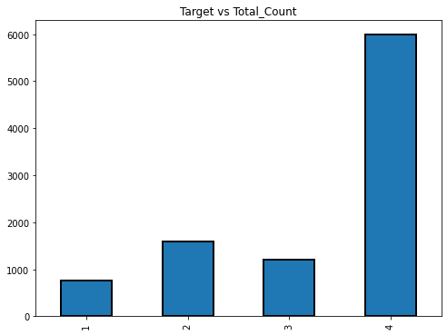

```python
target_counts.plot.bar(figsize = (8, 6),linewidth = 2,edgecolor = 'k',title="Target vs Total_Count")
```

### Above analysis shows that the training data is biased

## 4. Count how many null values are existing in columns.

```python
null_counts=train.select_dtypes('float').isnull().sum() # counting null values for float features
null_counts[null_counts > 0]
```

```
v2a1         6860
v18q1        7342
rez_esc      7928
meaneduc        5
SQBmeaned       5
dtype: int64
```

```python
null_counts=train.select_dtypes('object').isnull().sum() # counting null values for object features
null_counts[null_counts > 0]
```

```
Series([], dtype: int64)
```

```python
null_counts=train.select_dtypes('int64').isnull().sum() # counting null values for int features
null_counts[null_counts > 0]
```

```
Series([], dtype: int64)
```

#### Handling Null values for 'v2a1 ' - Monthly rent payment.

#### Checking for features related with home:

tipovivi1, =1 own and fully paid house tipovivi2, =1 own, paying in installments tipovivi3, =1 rented tipovivi4, =1 precarious tipovivi5, =1 other(assigned, borrowed)

```python
data =train[train['v2a1'].isnull()]

columns=['tipovivi1','tipovivi2','tipovivi3','tipovivi4','tipovivi5']
data[columns]
```

|  | tipovivi1 | tipovivi2 | tipovivi3 | tipovivi4 | tipovivi5 |
| --- | --- | --- | --- | --- | --- |
| 2 | 1 | 0 | 0 | 0 | 0 |
| 13 | 1 | 0 | 0 | 0 | 0 |
| 14 | 1 | 0 | 0 | 0 | 0 |
| 26 | 1 | 0 | 0 | 0 | 0 |
| 32 | 1 | 0 | 0 | 0 | 0 |
| ... | ... | ... | ... | ... | ... |
| 9542 | 1 | 0 | 0 | 0 | 0 |
| 9543 | 1 | 0 | 0 | 0 | 0 |
| 9544 | 1 | 0 | 0 | 0 | 0 |
| 9550 | 1 | 0 | 0 | 0 | 0 |
| 9551 | 1 | 0 | 0 | 0 | 0 |

6860 rows × 5 columns

```python
data['tipovivi1'].value_counts()
```

```
1    5911
0     949
Name: tipovivi1, dtype: int64
```

```python
data['tipovivi2'].value_counts()
```

```
0    6860
Name: tipovivi2, dtype: int64
```

```python
data['tipovivi3'].value_counts()
```

```
0    6860
Name: tipovivi3, dtype: int64
```

```python
data['tipovivi4'].value_counts()
```

```
0    6697
1     163
Name: tipovivi4, dtype: int64
```

```python
data['tipovivi5'].value_counts()
```

```
0    6074
1     786
Name: tipovivi5, dtype: int64
```

```python
#Looking at the above data it makes sense that when the house is fully paid, there will be no monthly rent payment.
#Lets add 0 for all the null values.
for df in [train,test]:
    df['v2a1'].fillna(value=0, inplace=True)
```

#### Handling Null values for 'v18q'- owns a tablet.

#### Checking for features related with tablet:

v18q = owns a tablet v18q1 = number of tablets household owns

```python
data1 =train[train['v18q1'].isnull()]
columns=['v18q','v18q1']
data1[columns]
```

|  | v18q | v18q1 |
| --- | --- | --- |
| 0 | 0 | NaN |
| 2 | 0 | NaN |
| 7 | 0 | NaN |
| 8 | 0 | NaN |
| 9 | 0 | NaN |
| ... | ... | ... |
| 9552 | 0 | NaN |
| 9553 | 0 | NaN |
| 9554 | 0 | NaN |
| 9555 | 0 | NaN |
| 9556 | 0 | NaN |

7342 rows × 2 columns

```python
data1['v18q'].value_counts()
```

```
0    7342
Name: v18q, dtype: int64
```

```python
data1['v18q1'].value_counts()
```

```
Series([], Name: v18q1, dtype: int64)
```

```python
#Looking at the above data it makes sense that when no one owns a tablet in the home then, there will be no number of tablets household owns.
#Lets add 0 for all the null values.

for df in [train,test]:
    df['v18q1'].fillna(value=0, inplace=True)
```

#### Handling Null values for 'rez_esc'- Years behind in school.

```python
#Lets relate it with age and check
train[train['rez_esc'].notnull()]['age'].describe()
```

```
count    1629.000000
mean       12.258441
std         3.218325
min         7.000000
25%         9.000000
50%        12.000000
75%        15.000000
max        17.000000
Name: age, dtype: float64
```

#### This explains people within age of 7 and 17 don't miss the school

```python
data2 =train[train['rez_esc'].isnull()]
columns=['rez_esc','age']
print(data2['age'].value_counts())
```

```
23    189
20    179
18    179
30    178
19    170
     ...
92      6
97      6
93      5
95      2
10      1
Name: age, Length: 87, dtype: int64
```

```python
train.loc[train['rez_esc'].isnull()]['age'].describe()
```

```
count    7928.000000
mean       38.833249
std        20.989486
min         0.000000
25%        24.000000
50%        38.000000
75%        54.000000
max        97.000000
Name: age, dtype: float64
```

```python
train.loc[(train['rez_esc'].isnull() & ((train['age'] > 7) & (train['age'] < 17)))]['age']
```

```
2514    10
Name: age, dtype: int64
```

```python
train[(train['age'] ==10) & train['rez_esc'].isnull()].head()

#there is only one member in household for the member with age 10 and who is 'behind in school'. This explains why the member is
#behind in school.
```

|  | Id | v2a1 | hacdor | rooms | hacapo | v14a | refrig | v18q | v18q1 | r4h1 | ... | SQBescolari | SQBage | SQBhogar_total | SQBedjefe | SQBhogar_nin | SQBovercrowding | SQBdependency | SQBmeaned | agesq | Target |
| --- | --- | --- | --- | --- | --- | --- | --- | --- | --- | --- | --- | --- | --- | --- | --- | --- | --- | --- | --- | --- | --- |
| 2514 | ID_f012e4242 | 160000.0 | 0 | 6 | 0 | 1 | 1 | 1 | 1.0 | 0 | ... | 0 | 100 | 9 | 121 | 1 | 2.25 | 0.25 | 182.25 | 100 | 4 |

1 rows × 143 columns

```python
train[(train['Id'] =='ID_f012e4242')].head()
```

|  | Id | v2a1 | hacdor | rooms | hacapo | v14a | refrig | v18q | v18q1 | r4h1 | ... | SQBescolari | SQBage | SQBhogar_total | SQBedjefe | SQBhogar_nin | SQBovercrowding | SQBdependency | SQBmeaned | agesq | Target |
| --- | --- | --- | --- | --- | --- | --- | --- | --- | --- | --- | --- | --- | --- | --- | --- | --- | --- | --- | --- | --- | --- |
| 2514 | ID_f012e4242 | 160000.0 | 0 | 6 | 0 | 1 | 1 | 1 | 1.0 | 0 | ... | 0 | 100 | 9 | 121 | 1 | 2.25 | 0.25 | 182.25 | 100 | 4 |

1 rows × 143 columns

```python
for df in [train,test]:
    df['rez_esc'].fillna(value=0, inplace=True)
train[['rez_esc']].isnull().sum()
```

```
rez_esc    0
dtype: int64
```

#### Handling NUll value for - meaneduc,average years of education for adults (18+)

```python
train['meaneduc'].value_counts()
```

```
6.000000     846
11.000000    491
9.000000     398
8.500000     341
10.000000    330
            ...
23.500000      3
37.000000      3
0.333333       3
27.000000      2
32.000000      2
Name: meaneduc, Length: 155, dtype: int64
```

#### Checking with related field : instlevel1 =1 no level of education

```python
data3 =train[train['meaneduc'].isnull()]
columns=['meaneduc','instlevel1']
data3[columns].head()
```

|  | meaneduc | instlevel1 |
| --- | --- | --- |
| 1291 | NaN | 0 |
| 1840 | NaN | 0 |
| 1841 | NaN | 0 |
| 2049 | NaN | 0 |
| 2050 | NaN | 0 |

```python
data3['instlevel1'].value_counts()
```

```
0    5
Name: instlevel1, dtype: int64
```

```python
# from the above, we find that meaneduc is null when no level of education is 0
#Lets fix the data

for df in [train, test]:
    df['meaneduc'].fillna(value=0, inplace=True)
train[['meaneduc']].isnull().sum()
```

```
meaneduc    0
dtype: int64
```

#### Handling null values for SQBmeaned - square of the mean years of education of adults (>=18) in the household

```python
data4 =train[train['SQBmeaned'].isnull()]
columns=['SQBmeaned','instlevel1']
data4[columns].head()
```

|  | SQBmeaned | instlevel1 |
| --- | --- | --- |
| 1291 | NaN | 0 |
| 1840 | NaN | 0 |
| 1841 | NaN | 0 |
| 2049 | NaN | 0 |
| 2050 | NaN | 0 |

```python
# from the above, we find that SQBmeaned is null when no level of education is 0
#Lets fix the data
for df in [train, test]:
    df['SQBmeaned'].fillna(value=0, inplace=True)
train[['SQBmeaned']].isnull().sum()
```

```
SQBmeaned    0
dtype: int64
```

```python
#Lets look at the overall data
null_counts = train.isnull().sum()
null_counts[null_counts > 0].sort_values(ascending=False)
```

```
Series([], dtype: int64)
```

## 5. Check whether all members of the house have the same poverty level.

```python
train['idhogar'].value_counts()
```

```
2946    13
2034    12
150     12
816     11
2132    11
        ..
2957     1
908      1
876      1
2616     1
2027     1
Name: idhogar, Length: 2988, dtype: int64
```

```python
train['Target'].value_counts()
```

```
4    5996
2    1597
3    1209
1     755
Name: Target, dtype: int64
```

```python
# Finding if all memebers of a family has same poverty level
all_equal = train.groupby('idhogar')['Target'].apply(lambda x: x.nunique() == 1)
all_equal
```

```
idhogar
0       True
1       True
2       True
3       True
4       True
        ...
2983    True
2984    True
2985    True
2986    True
2987    True
Name: Target, Length: 2988, dtype: bool
```

```python
# Households where targets are not all equal
not_equal = all_equal[all_equal != True]
print('There are {} households where the family members do not all have the same target.'.format(len(not_equal)))
```

```
There are 85 households where the family members do not all have the same target.
```

```python
not_equal.index[0]
```

```
17
```

```python
#Lets check one household
train[train['idhogar'] == not_equal.index[0]][['idhogar', 'parentesco1', 'Target']]
```

|  | idhogar | parentesco1 | Target |
| --- | --- | --- | --- |
| 7651 | 17 | 0 | 3 |
| 7652 | 17 | 0 | 2 |
| 7653 | 17 | 0 | 3 |
| 7654 | 17 | 1 | 3 |
| 7655 | 17 | 0 | 2 |

## 6. Check if there is a house without a family head. .

```python
households_head = train.groupby('idhogar')['parentesco1'].sum()
households_head
```

```
idhogar
0       1
1       1
2       1
3       1
4       1
       ..
2983    1
2984    1
2985    1
2986    1
2987    1
Name: parentesco1, Length: 2988, dtype: int64
```

```python
# Find households without a head
households_no_head = train.loc[train['idhogar'].isin(households_head[households_head == 0].index), :]

print('There are {} households without a head.'.format(households_no_head['idhogar'].nunique()))
```

```
There are 15 households without a head.
```

```python
# Find households without a head and where Target value are different
households_no_head_equal = households_no_head.groupby('idhogar')['Target'].apply(lambda x: x.nunique() == 1)
print('{} Households with no head have different Target value.'.format(sum(households_no_head_equal == False)))
```

```
0 Households with no head have different Target value.
```

## 7. Set poverty level of the members and the head of the house within a family.

```python
#Lets fix the data
#Set poverty level of the members and the head of the house within a family.
# Iterate through each household
for household in not_equal.index:
    # Find the correct label (for the head of household)
    true_target = int(train[(train['idhogar'] == household) & (train['parentesco1'] == 1.0)]['Target'])

    # Set the correct label for all members in the household
    train.loc[train['idhogar'] == household, 'Target'] = true_target


# Groupby the household and figure out the number of unique values
all_equal = train.groupby('idhogar')['Target'].apply(lambda x: x.nunique() == 1)

# Households where targets are not all equal
not_equal = all_equal[all_equal != True]
print('There are {} households where the family members do not all have the same target.'.format(len(not_equal)))
```

```
There are 0 households where the family members do not all have the same target.
```

#### Lets look at the Squared Variables

‘SQBescolari’ ‘SQBage’ ‘SQBhogar_total’ ‘SQBedjefe’ ‘SQBhogar_nin’ ‘SQBovercrowding’ ‘SQBdependency’ ‘SQBmeaned’ ‘agesq’

```python
#Lets remove them
print(train.shape)
cols=['SQBescolari', 'SQBage', 'SQBhogar_total', 'SQBedjefe',
        'SQBhogar_nin', 'SQBovercrowding', 'SQBdependency', 'SQBmeaned', 'agesq']


for df in [train, test]:
    df.drop(columns = cols,inplace=True)
```

```
(9557, 143)
```

```python
train['Target'].isnull().sum()
```

```
0
```

```python
train.select_dtypes('object')
```

|  | Id |
| --- | --- |
| 0 | ID_279628684 |
| 1 | ID_f29eb3ddd |
| 2 | ID_68de51c94 |
| 3 | ID_d671db89c |
| 4 | ID_d56d6f5f5 |
| ... | ... |
| 9552 | ID_d45ae367d |
| 9553 | ID_c94744e07 |
| 9554 | ID_85fc658f8 |
| 9555 | ID_ced540c61 |
| 9556 | ID_a38c64491 |

9557 rows × 1 columns

```python
test_columns = test.columns
```

```python
train_columns = train.columns
```

```python
test_id =test['Id']
```

```python
train_id=train['Id']
```

```python
train.drop('Id',axis=1,inplace=True)
```

```python
test.drop('Id',axis=1,inplace=True)
```

```python
y = train['Target']
```

```python
train.drop('Target',axis=1,inplace=True)
```

```python
X = train
```

```python
from sklearn.model_selection import train_test_split

X_train, X_test, y_train, y_test = train_test_split(X, y, test_size=0.2)
```

## 8. Predict the accuracy using random forest classifier.

```python
from sklearn.ensemble import RandomForestClassifier
from sklearn.model_selection import train_test_split
from sklearn.metrics import accuracy_score,confusion_matrix,f1_score,classification_report
```

```python
RFC = RandomForestClassifier()
```

```python
RFC.fit(X_train,y_train)
```

```
RandomForestClassifier(bootstrap=True, class_weight=None, criterion='gini',
                       max_depth=None, max_features='auto', max_leaf_nodes=None,
                       min_impurity_decrease=0.0, min_impurity_split=None,
                       min_samples_leaf=1, min_samples_split=2,
                       min_weight_fraction_leaf=0.0, n_estimators=10,
                       n_jobs=None, oob_score=False, random_state=None,
                       verbose=0, warm_start=False)
```

```python
y_predict_withoutCV = RFC.predict(X_test)
```

```python
print(accuracy_score(y_test,y_predict_withoutCV))
print(confusion_matrix(y_test,y_predict_withoutCV))
print(classification_report(y_test,y_predict_withoutCV))
```

```
0.9157949790794979
[[ 123   17    1   22]
 [   3  263    3   36]
 [   3    9  185   40]
 [   1   16   10 1180]]
              precision    recall  f1-score   support

           1       0.95      0.75      0.84       163
           2       0.86      0.86      0.86       305
           3       0.93      0.78      0.85       237
           4       0.92      0.98      0.95      1207

    accuracy                           0.92      1912
   macro avg       0.92      0.84      0.88      1912
weighted avg       0.92      0.92      0.91      1912
```

```python
y_predict_test_withoutcv = RFC.predict(test)
```

```python
y_predict_test_withoutcv
```

```
array([4, 4, 4, ..., 1, 1, 3], dtype=int64)
```

## 9. Check the accuracy using random forest with cross validation.

```python
from sklearn.model_selection import KFold,cross_val_score
```

```python
seed=7
kfold=KFold(n_splits=5,random_state=seed,shuffle=True)

RFC = RandomForestClassifier(random_state=10,n_jobs = -1)
```

```python
print(cross_val_score(RFC ,X,y,cv=kfold,scoring='accuracy'))
results=cross_val_score(RFC,X,y,cv=kfold,scoring='accuracy')
print(results.mean()*100)
```

```
[0.93514644 0.93462343 0.92883307 0.9314495  0.9277865 ]
```

```
93.15677896520694
```

```python
#Increasing the number of trees
num_trees= 100

RFC = RandomForestClassifier(n_estimators=100, random_state=10,n_jobs = -1)
print(cross_val_score(RFC,X,y,cv=kfold,scoring='accuracy'))
results=cross_val_score(RFC,X,y,cv=kfold,scoring='accuracy')
print(results.mean()*100)
```

```
[0.95031381 0.95292887 0.94767138 0.9392988  0.94924123]
94.78908170928493
```

```python
from sklearn.model_selection import GridSearchCV
from sklearn.model_selection import StratifiedKFold
```

```python
import numpy as np
from sklearn.model_selection import RandomizedSearchCV
# Number of trees in random forest
n_estimators = [int(x) for x in np.linspace(start = 200, stop = 2000, num = 10)]
# Number of features to consider at every split
max_features = ['auto', 'sqrt','log2']
# Maximum number of levels in tree
max_depth = [int(x) for x in np.linspace(10, 1000,10)]
# Minimum number of samples required to split a node
min_samples_split = [2, 5, 10,14]
# Minimum number of samples required at each leaf node
min_samples_leaf = [1, 2, 4,6,8]
# Create the random grid
random_grid = {'n_estimators': n_estimators,
               'max_features': max_features,
               'max_depth': max_depth,
               'min_samples_split': min_samples_split,
               'min_samples_leaf': min_samples_leaf,
              'criterion':['entropy','gini']}
print(random_grid)
```

```
{'n_estimators': [200, 400, 600, 800, 1000, 1200, 1400, 1600, 1800, 2000], 'max_features': ['auto', 'sqrt', 'log2'], 'max_depth': [10, 120, 230, 340, 450, 560, 670, 780, 890, 1000], 'min_samples_split': [2, 5, 10, 14], 'min_samples_leaf': [1, 2, 4, 6, 8], 'criterion': ['entropy', 'gini']}
```

```python
#### Since the target is biased , using stratified k fold CV
```

```python
random_search = RandomizedSearchCV(RFC,param_distributions=random_grid,n_iter=100,n_jobs=-1, cv = StratifiedKFold(n_splits=5),verbose=3)  # Hyperparameter tuning
```

```python
random_search.fit(X_train, y_train)
```

```
Fitting 5 folds for each of 100 candidates, totalling 500 fits
```

```
[Parallel(n_jobs=-1)]: Using backend LokyBackend with 4 concurrent workers.
[Parallel(n_jobs=-1)]: Done  24 tasks      | elapsed:  2.7min
[Parallel(n_jobs=-1)]: Done 120 tasks      | elapsed: 16.5min
[Parallel(n_jobs=-1)]: Done 280 tasks      | elapsed: 33.0min
[Parallel(n_jobs=-1)]: Done 500 out of 500 | elapsed: 61.1min finished
```

```
RandomizedSearchCV(cv=StratifiedKFold(n_splits=5, random_state=None, shuffle=False),
                   error_score='raise-deprecating',
                   estimator=RandomForestClassifier(bootstrap=True,
                                                    class_weight=None,
                                                    criterion='gini',
                                                    max_depth=None,
                                                    max_features='auto',
                                                    max_leaf_nodes=None,
                                                    min_impurity_decrease=0.0,
                                                    min_impurity_split=None,
                                                    min_samples_leaf=1,
                                                    min_samples_split=2,
                                                    min_weigh...
                   param_distributions={'criterion': ['entropy', 'gini'],
                                        'max_depth': [10, 120, 230, 340, 450,
                                                      560, 670, 780, 890,
                                                      1000],
                                        'max_features': ['auto', 'sqrt',
                                                         'log2'],
                                        'min_samples_leaf': [1, 2, 4, 6, 8],
                                        'min_samples_split': [2, 5, 10, 14],
                                        'n_estimators': [200, 400, 600, 800,
                                                         1000, 1200, 1400, 1600,
                                                         1800, 2000]},
                   pre_dispatch='2*n_jobs', random_state=None, refit=True,
                   return_train_score=False, scoring=None, verbose=3)
```

```python
random_search.best_params_
```

```
{'n_estimators': 1600,
 'min_samples_split': 2,
 'min_samples_leaf': 1,
 'max_features': 'auto',
 'max_depth': 1000,
 'criterion': 'gini'}
```

```python
best_random_grid=random_search.best_estimator_
```

```python
from sklearn.metrics import confusion_matrix,classification_report,accuracy_score
y_pred=best_random_grid.predict(X_test)
print(confusion_matrix(y_test,y_pred))
print("Accuracy Score {}".format(accuracy_score(y_test,y_pred)))
print("Classification report: {}".format(classification_report(y_test,y_pred)))
```

```
[[ 142    4    0   17]
 [   0  281    1   23]
 [   3    0  200   34]
 [   0    1    1 1205]]
Accuracy Score 0.9560669456066946
Classification report:               precision    recall  f1-score   support

           1       0.98      0.87      0.92       163
           2       0.98      0.92      0.95       305
           3       0.99      0.84      0.91       237
           4       0.94      1.00      0.97      1207

    accuracy                           0.96      1912
   macro avg       0.97      0.91      0.94      1912
weighted avg       0.96      0.96      0.96      1912
```

```python
from sklearn.model_selection import GridSearchCV

param_grid = {
    'criterion': [random_search.best_params_['criterion']],
    'max_depth': [random_search.best_params_['max_depth']],
    'max_features': [random_search.best_params_['max_features']],
    'min_samples_leaf': [random_search.best_params_['min_samples_leaf'],
                         random_search.best_params_['min_samples_leaf']+2,
                         random_search.best_params_['min_samples_leaf'] + 4],
    'min_samples_split': [random_search.best_params_['min_samples_split'] + 3,
                          random_search.best_params_['min_samples_split'] + 4,
                          random_search.best_params_['min_samples_split'],
                          random_search.best_params_['min_samples_split'] +1,
                          random_search.best_params_['min_samples_split'] + 2],
    'n_estimators': [random_search.best_params_['n_estimators'] - 200, random_search.best_params_['n_estimators'] - 100,
                     random_search.best_params_['n_estimators'],
                     random_search.best_params_['n_estimators'] + 100, random_search.best_params_['n_estimators'] + 200]
}

print(param_grid)
```

```
{'criterion': ['gini'], 'max_depth': [1000], 'max_features': ['auto'], 'min_samples_leaf': [1, 3, 5], 'min_samples_split': [5, 6, 2, 3, 4], 'n_estimators': [1400, 1500, 1600, 1700, 1800]}
```

```python
RFC1=RandomForestClassifier()
grid_search=GridSearchCV(estimator=RFC1,param_grid=param_grid, cv = StratifiedKFold(n_splits=5),n_jobs=-1,verbose=2)
grid_search.fit(X_train,y_train)
```

```
Fitting 5 folds for each of 75 candidates, totalling 375 fits
```

```
[Parallel(n_jobs=-1)]: Using backend LokyBackend with 4 concurrent workers.
[Parallel(n_jobs=-1)]: Done  33 tasks      | elapsed:  8.2min
[Parallel(n_jobs=-1)]: Done 154 tasks      | elapsed: 35.0min
[Parallel(n_jobs=-1)]: Done 357 tasks      | elapsed: 77.2min
[Parallel(n_jobs=-1)]: Done 375 out of 375 | elapsed: 80.3min finished
```

```
GridSearchCV(cv=StratifiedKFold(n_splits=5, random_state=None, shuffle=False),
             error_score='raise-deprecating',
             estimator=RandomForestClassifier(bootstrap=True, class_weight=None,
                                              criterion='gini', max_depth=None,
                                              max_features='auto',
                                              max_leaf_nodes=None,
                                              min_impurity_decrease=0.0,
                                              min_impurity_split=None,
                                              min_samples_leaf=1,
                                              min_samples_split=2,
                                              min_weight_frac...
                                              n_estimators='warn', n_jobs=None,
                                              oob_score=False,
                                              random_state=None, verbose=0,
                                              warm_start=False),
             iid='warn', n_jobs=-1,
             param_grid={'criterion': ['gini'], 'max_depth': [1000],
                         'max_features': ['auto'],
                         'min_samples_leaf': [1, 3, 5],
                         'min_samples_split': [5, 6, 2, 3, 4],
                         'n_estimators': [1400, 1500, 1600, 1700, 1800]},
             pre_dispatch='2*n_jobs', refit=True, return_train_score=False,
             scoring=None, verbose=2)
```

```python
grid_search.best_estimator_
```

```
RandomForestClassifier(bootstrap=True, class_weight=None, criterion='gini',
                       max_depth=1000, max_features='auto', max_leaf_nodes=None,
                       min_impurity_decrease=0.0, min_impurity_split=None,
                       min_samples_leaf=1, min_samples_split=2,
                       min_weight_fraction_leaf=0.0, n_estimators=1600,
                       n_jobs=None, oob_score=False, random_state=None,
                       verbose=0, warm_start=False)
```

```python
best_grid=grid_search.best_estimator_
```

```python
best_grid
```

```
RandomForestClassifier(bootstrap=True, class_weight=None, criterion='gini',
                       max_depth=1000, max_features='auto', max_leaf_nodes=None,
                       min_impurity_decrease=0.0, min_impurity_split=None,
                       min_samples_leaf=1, min_samples_split=2,
                       min_weight_fraction_leaf=0.0, n_estimators=1600,
                       n_jobs=None, oob_score=False, random_state=None,
                       verbose=0, warm_start=False)
```

```python
y_pred=best_grid.predict(X_test)
print(confusion_matrix(y_test,y_pred))
print("Accuracy Score {}".format(accuracy_score(y_test,y_pred)))
print("Classification report: {}".format(classification_report(y_test,y_pred)))
```

```
[[ 141    4    0   18]
 [   0  284    1   20]
 [   3    0  200   34]
 [   0    1    1 1205]]
Accuracy Score 0.9571129707112971
Classification report:               precision    recall  f1-score   support

           1       0.98      0.87      0.92       163
           2       0.98      0.93      0.96       305
           3       0.99      0.84      0.91       237
           4       0.94      1.00      0.97      1207

    accuracy                           0.96      1912
   macro avg       0.97      0.91      0.94      1912
weighted avg       0.96      0.96      0.96      1912
```

```python
y_predictions = best_grid.predict(test)
```

```python
y_predictions
```

```
array([4, 4, 4, ..., 4, 4, 4], dtype=int64)
```

### Accuracy of RFC without CV and Hypertuning - 0.9157949790794979

### Accuracy of RFC with CV - 93.15677896520694

### Accuracy of RFC with CV and 100 Decision Tress - 94.78908170928493

### Accuracy of RFC with Stratified 5 fold CV and Hyperparameter tuning with RandomizedSearchCV - 0.9560669456066946

### Accuracy of RFC with Stratified 5 fold CV and Hyperparameter tuning with GridSearchCV 0.9571129707112971